# Business process analysis for the MEDC database

Greg Hood, Analytics and Innovation, Biosecurity Strategy and Reform

03 August 2021

# Overview

Business process analysis (BPA) or [process mining](https://en.wikipedia.org/wiki/Process_mining) is a technique that can be used to understand what people, computer systems and organisations are doing. In most organisations, people usually start to analyse business processes by constructing models or flow diagrams to depict the key events and how one flows into another. Diagrams depicting such models are commonly constructed manually using a word processor or diagramming tool after discussions with subject matter experts (SMEs). When done well, construction and discussion of these models can promote a common understanding of a business process and lead to well-understood and measurable performance criteria.

Manual processes, however, have some limitations:

- they depend on an accurate understanding of the process by SMEs
- often ignore uncommon or exceptional processes
- do not provide a quantitative view of the process
- can be relatively slow because of the requirement to transfer knowledge from SMEs to the analyst.

BPA as defined here, however, is an automated method for analysis of a business processes. It starts from event data recorded in a database – in the form of time or date stamps – which is massaged into a formal structure called an ‘event log’. If appropriate data is available, this automated method can avoid the problems listed above and provide regular and, sometimes, real-time analysis of a business process.

This document is a preliminary exploration of the potential of the department’s MEDC database to support BPA and provide regular analyses of the meat hygiene testing system.

# Data source

To get the process started, we developed an SQL query that interrogates the T2_EXPORTS database created by the Analytics Centre from the MEDC database. The advantage of doing so is that T2_EXPORTS provides a clear, business-oriented view of key events. (The raw MEDC database, like most transactional systems, is in what is called a highly normalised form that is best suited for interrogation by database experts rather than analysts.)

The SQL query generates a dataset from the ‘CartonMeatStec’ table, which, for each STEC test, includes the date of the production run and the date of the test. For some records it also includes the date of confirmation.

Table 1: Example of events extracted from STEC tests in MEDC (in the bupaR format – see https://www.bupar.net/creating_eventlogs.html).

| Stec ID | Activity | Start datetime | Destination | Status | Activity instance |
| --- | --- | --- | --- | --- | --- |
| 129709 | Production | 2021-01-14 | USA | Start | 296 |
| 129709 | Test | 2021-01-19 | USA | Start | 7300 |
| 129709 | Confirmed | 2021-01-19 | USA | Start | 14014 |
| 129959 | Production | 2021-01-21 | USA | Start | 381 |
| 129959 | Test | 2021-01-21 | USA | Start | 7385 |
| 129959 | Confirmed | 2021-01-22 | USA | Start | 14017 |
| 130941 | Production | 2021-02-01 | USA | Start | 541 |
| 130941 | Test | 2021-02-01 | USA | Start | 7545 |
| 130941 | Confirmed | 2021-02-05 | USA | Start | 14020 |

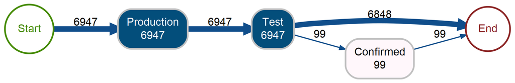

And a map of event durations shows the intervals between a production run and a test and between a test and confirmation.

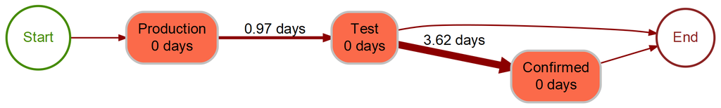

# Further work

BPA using MEDC seems possible, although the coverage and accuracy of the data appears to be poor. More investigation seems warranted.